# Naïve Bayes in Python

## Introduction to Naïve Bayes

1. Naive Bayes classification, grounded in Bayes’ theorem, is a supervised machine learning algorithm designed to categorize items into pre-established labels, it is famous for its proficiency in text-analysis.
2. The Naive Bayes classification use the Bayes theorem as foundation, the Bayes theorem is given by the conditional probability of some hypothesis given some evidence, the function of the Bayes theorem is given by : $P(A|B) = \frac{P(B|A) \cdot P(A)}{P(B)}$.
3. According to the name “Naive Bayes Classifier”, the object of the supervised machine learning method is having the ability to classify or predict object’s label based on the given labels. The algorithm aims to calculate the probability of each class given a set of input features and then assigns the class with the highest probability as the predicted class for the input.
- The Gaussian Naive Bayes is used when assume our label/feature data has a normal distribution, it is best suitable for continuous data with a normal distribution.
- The multinational Naive Bayes is implemented if the data has a discrete variable, it is best suitable for text classification.
- Bernoulli Naive Bayes is used on binary data, it is best suitable for document classification where it is either present or absence.

## Data preparation for Naïve Bayes

### Load the cleaned data of the [Framingham Heart Study Longitudinal Data](https://www.framinghamheartstudy.org/fhs-for-researchers/data-available-overview/),

- For this part of analysis, I will be using cardiovascular diseases `(CVD)` as my target variable.

```python
import pandas as pd
import numpy as np
from sklearn.model_selection import train_test_split
from sklearn.naive_bayes import GaussianNB
from sklearn.metrics import accuracy_score, confusion_matrix, classification_report
import matplotlib.pyplot as plt
import seaborn as sns
from sklearn.feature_selection import f_classif, SelectKBest
from sklearn.metrics import roc_curve, auc
from sklearn.metrics import accuracy_score, precision_score, recall_score, f1_score

# Load the Frammingham Heart Study data set
data = pd.read_csv("data/frmgham2.csv")
data.head()
data.describe
```

```
<bound method NDFrame.describe of         RANDID  SEX  TOTCHOL  AGE  SYSBP  DIABP  CURSMOKE  CIGPDAY    BMI  \
0         2448    1    195.0   39  106.0   70.0         0      0.0  26.97
1         2448    1    209.0   52  121.0   66.0         0      0.0    NaN
2         6238    2    250.0   46  121.0   81.0         0      0.0  28.73
3         6238    2    260.0   52  105.0   69.5         0      0.0  29.43
4         6238    2    237.0   58  108.0   66.0         0      0.0  28.50
...        ...  ...      ...  ...    ...    ...       ...      ...    ...
11622  9998212    1    173.0   46  126.0   82.0         0      0.0  19.17
11623  9998212    1    153.0   52  143.0   89.0         0      0.0  25.74
11624  9999312    2    196.0   39  133.0   86.0         1     30.0  20.91
11625  9999312    2    240.0   46  138.0   79.0         1     20.0  26.39
11626  9999312    2      NaN   50  147.0   96.0         1     10.0  24.19

       DIABETES  ...  CVD  HYPERTEN  TIMEAP  TIMEMI  TIMEMIFC  TIMECHD  \
0             0  ...    1         0    8766    6438      6438     6438
```

[output cut: 25 more lines]

### Missing data handeling

```python
# missing data handeling
print(data.isna().sum())
#data.dropna()
```

```
RANDID         0
SEX            0
TOTCHOL      409
AGE            0
SYSBP          0
DIABP          0
CURSMOKE       0
CIGPDAY       79
BMI           52
DIABETES       0
BPMEDS       593
HEARTRTE       6
GLUCOSE     1440
educ         295
PREVCHD        0
PREVAP         0
PREVMI         0
PREVSTRK       0
PREVHYP        0
TIME           0
PERIOD         0
HDLC        8600
LDLC        8601
DEATH          0
ANGINA         0
HOSPMI         0
MI_FCHD        0
ANYCHD         0
STROKE         0
CVD            0
HYPERTEN       0
TIMEAP         0
TIMEMI         0
TIMEMIFC       0
TIMECHD        0
TIMESTRK       0
TIMECVD        0
TIMEDTH        0
TIMEHYP        0
dtype: int64
```

- Removing data variables that has `30%` or more of missing data

```python
# Calculate the percentage of missing data in each column
missing_percentage = (data.isna().sum() / len(data)) * 100

# Set the threshold for missing data (30%)
threshold = 30

# Identify columns with missing data exceeding the threshold
columns_to_remove = missing_percentage[missing_percentage > threshold].index
print(columns_to_remove)

# Remove the identified columns from the DataFrame
data = data.drop(columns=columns_to_remove)
data.dropna(inplace=True)

data.head()
```

```
Index(['HDLC', 'LDLC'], dtype='object')
```

|  | RANDID | SEX | TOTCHOL | AGE | SYSBP | DIABP | CURSMOKE | CIGPDAY | BMI | DIABETES | ... | CVD | HYPERTEN | TIMEAP | TIMEMI | TIMEMIFC | TIMECHD | TIMESTRK | TIMECVD | TIMEDTH | TIMEHYP |
| --- | --- | --- | --- | --- | --- | --- | --- | --- | --- | --- | --- | --- | --- | --- | --- | --- | --- | --- | --- | --- | --- |
| 0 | 2448 | 1 | 195.0 | 39 | 106.0 | 70.0 | 0 | 0.0 | 26.97 | 0 | ... | 1 | 0 | 8766 | 6438 | 6438 | 6438 | 8766 | 6438 | 8766 | 8766 |
| 2 | 6238 | 2 | 250.0 | 46 | 121.0 | 81.0 | 0 | 0.0 | 28.73 | 0 | ... | 0 | 0 | 8766 | 8766 | 8766 | 8766 | 8766 | 8766 | 8766 | 8766 |
| 3 | 6238 | 2 | 260.0 | 52 | 105.0 | 69.5 | 0 | 0.0 | 29.43 | 0 | ... | 0 | 0 | 8766 | 8766 | 8766 | 8766 | 8766 | 8766 | 8766 | 8766 |
| 4 | 6238 | 2 | 237.0 | 58 | 108.0 | 66.0 | 0 | 0.0 | 28.50 | 0 | ... | 0 | 0 | 8766 | 8766 | 8766 | 8766 | 8766 | 8766 | 8766 | 8766 |
| 5 | 9428 | 1 | 245.0 | 48 | 127.5 | 80.0 | 1 | 20.0 | 25.34 | 0 | ... | 0 | 0 | 8766 | 8766 | 8766 | 8766 | 8766 | 8766 | 8766 | 8766 |

5 rows × 37 columns

### Split data into train/test/validation sets

```python
# Split target variables and predictor variables
X = data.drop('CVD', axis=1)
y = data['CVD']

X_train, X_test, y_train, y_test = train_test_split(X, y, test_size=0.2, random_state=42)
X_train, X_val, y_train, y_val = train_test_split(X_train, y_train, test_size=0.25, random_state=42)

X_train.head()
```

|  | RANDID | SEX | TOTCHOL | AGE | SYSBP | DIABP | CURSMOKE | CIGPDAY | BMI | DIABETES | ... | STROKE | HYPERTEN | TIMEAP | TIMEMI | TIMEMIFC | TIMECHD | TIMESTRK | TIMECVD | TIMEDTH | TIMEHYP |
| --- | --- | --- | --- | --- | --- | --- | --- | --- | --- | --- | --- | --- | --- | --- | --- | --- | --- | --- | --- | --- | --- |
| 1593 | 1333048 | 2 | 241.0 | 71 | 193.0 | 106.0 | 1 | 20.0 | 18.63 | 0 | ... | 1 | 1 | 8766 | 8766 | 8766 | 8766 | 5378 | 5378 | 8766 | 0 |
| 66 | 55965 | 2 | 256.0 | 66 | 126.0 | 82.0 | 0 | 0.0 | 25.43 | 0 | ... | 0 | 1 | 8297 | 8766 | 8766 | 8297 | 8766 | 8766 | 8766 | 7951 |
| 1581 | 1315580 | 1 | 259.0 | 64 | 121.0 | 65.0 | 1 | 20.0 | 21.19 | 0 | ... | 0 | 1 | 8766 | 8766 | 8766 | 8766 | 8766 | 8766 | 8766 | 8178 |
| 11247 | 9655204 | 2 | 238.0 | 51 | 123.0 | 80.0 | 0 | 0.0 | 22.19 | 0 | ... | 0 | 1 | 8766 | 8766 | 8766 | 8766 | 8766 | 8766 | 8766 | 0 |
| 8354 | 7206124 | 2 | 287.0 | 69 | 209.0 | 98.0 | 0 | 0.0 | 26.57 | 0 | ... | 0 | 1 | 8766 | 8766 | 8766 | 8766 | 8766 | 8766 | 8766 | 0 |

5 rows × 36 columns

The objective for spliting data into train/test/validation sets is to prevent model from overfitting and improve generalization of the model.

## Feature selection using ANOVA F-test

```python
s= SelectKBest(score_func=f_classif, k=25)
X_new = s.fit_transform(X, y)
sf = X.columns[s.get_support()]
print("Selected features:", sf)
```

```
Selected features: Index(['SEX', 'AGE', 'SYSBP', 'DIABP', 'DIABETES', 'PREVCHD', 'PREVAP',
       'PREVMI', 'PREVSTRK', 'PREVHYP', 'DEATH', 'ANGINA', 'HOSPMI', 'MI_FCHD',
       'ANYCHD', 'STROKE', 'HYPERTEN', 'TIMEAP', 'TIMEMI', 'TIMEMIFC',
       'TIMECHD', 'TIMESTRK', 'TIMECVD', 'TIMEDTH', 'TIMEHYP'],
      dtype='object')
```

## Model training

### Training sets results

```python
# Train the Naive Bayes model using selected features
nb_model = GaussianNB()
nb_model.fit(X_train[sf], y_train)

# Obtain evaluation metrics for both training sets/validation sets
y_train_pred = nb_model.predict(X_train[sf])
y_val_pred = nb_model.predict(X_val[sf])

val_accuracy = accuracy_score(y_val, y_val_pred)
train_accuracy = accuracy_score( y_train, y_train_pred)

print(f"Accuracy for training set: {train_accuracy}")
print(classification_report( y_train, y_train_pred))
```

```
Accuracy for training set: 0.899391335481561
              precision    recall  f1-score   support

           0       0.96      0.90      0.93      4188
           1       0.75      0.89      0.82      1398

    accuracy                           0.90      5586
   macro avg       0.86      0.90      0.87      5586
weighted avg       0.91      0.90      0.90      5586
```

### Validation sets results

```python
print(f"Accuracy for validation set: {val_accuracy}")
print(classification_report(y_val, y_val_pred))

# Confusion Matrix for Validation Data
cm_val = confusion_matrix(y_val, y_val_pred)
print(cm_val)
```

```
Accuracy for validation set: 0.916219119226638
              precision    recall  f1-score   support

           0       0.97      0.92      0.94      1385
           1       0.79      0.91      0.85       477

    accuracy                           0.92      1862
   macro avg       0.88      0.91      0.89      1862
weighted avg       0.92      0.92      0.92      1862

[[1272  113]
 [  43  434]]
```

- **Interpretation** :

The Naive Bayes classifier works really well when tested, showing high levels of correct predictions and a good balance in its ability to identify true cases of the condition it’s predicting. The F1-scores, which combine precision and recall, are also high, indicating the model is consistent in its predictions. Moreover, the model is slightly more accurate on the vaildation data than on the data it was trained on, which suggests its generalization when used in real-world data. Also, the high accuracy score on validation sets also indicates that the model neither over-fitting nor under-fitting, but reaching a balance between the two. Overall, these results highlight the model as a dependable tool for predictive modelling.

## Visualizations

### Confusion matrix heatmap

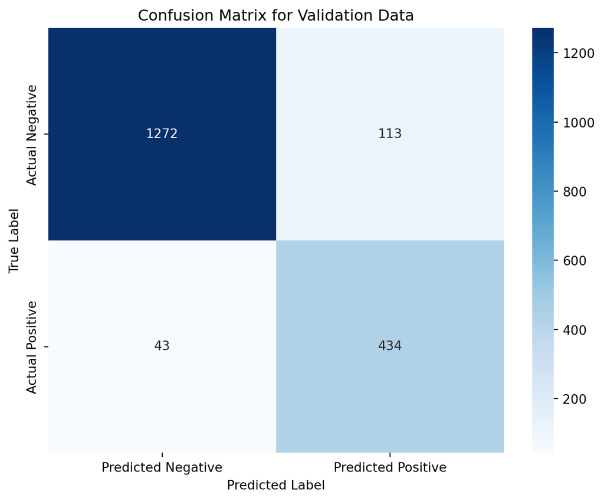

```python
# Confusion Matrix Heatmap
plt.figure(figsize=(8, 6))
sns.heatmap(cm_val, annot=True, fmt='d', cmap='Blues', xticklabels=['Predicted Negative', 'Predicted Positive'], yticklabels=['Actual Negative', 'Actual Positive'])
plt.title('Confusion Matrix for Validation Data')
plt.ylabel('True Label')
plt.xlabel('Predicted Label')
plt.show()
```

The confusion matrix heatmap is a visual interpretation of the fitted model.

### Accuracy evaluation bar plots

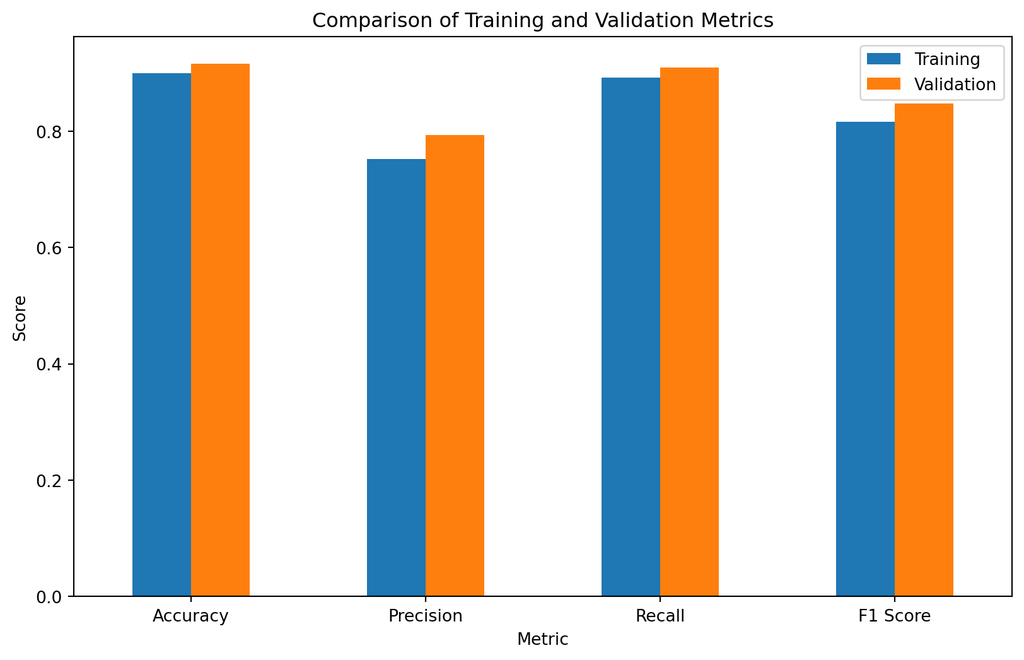

```python
# Metrics for the training set
ta = accuracy_score(y_train, y_train_pred)
tp = precision_score(y_train, y_train_pred)
tr = recall_score(y_train, y_train_pred)
tf1 = f1_score(y_train, y_train_pred)

# Metrics for the validation set
va = accuracy_score(y_val, y_val_pred)
vp = precision_score(y_val, y_val_pred)
vr = recall_score(y_val, y_val_pred)
vf1 = f1_score(y_val, y_val_pred)

# Bar plot of accuracy metrics
metrics_df = pd.DataFrame({
    'Metric': ['Accuracy', 'Precision', 'Recall', 'F1 Score'],
    'Training': [ta, tp, tr, tf1],
    'Validation': [va, vp, vr, vf1]
})

metrics_df.set_index('Metric', inplace=True)
metrics_df.plot.bar(rot=0, figsize=(10, 6))
plt.title('Comparison of Training and Validation Metrics')
plt.ylabel('Score')
plt.show()
```

The bar plot demonstrates comparison of scores of Accuracy, precisoin, recall, and F-1 score between training and validation models, with higher scores on every metrics of the validation models, suggesting that the model learns well on the training data and also performs strongly on unseen data, suggesting a good model performance.

### ROC curve

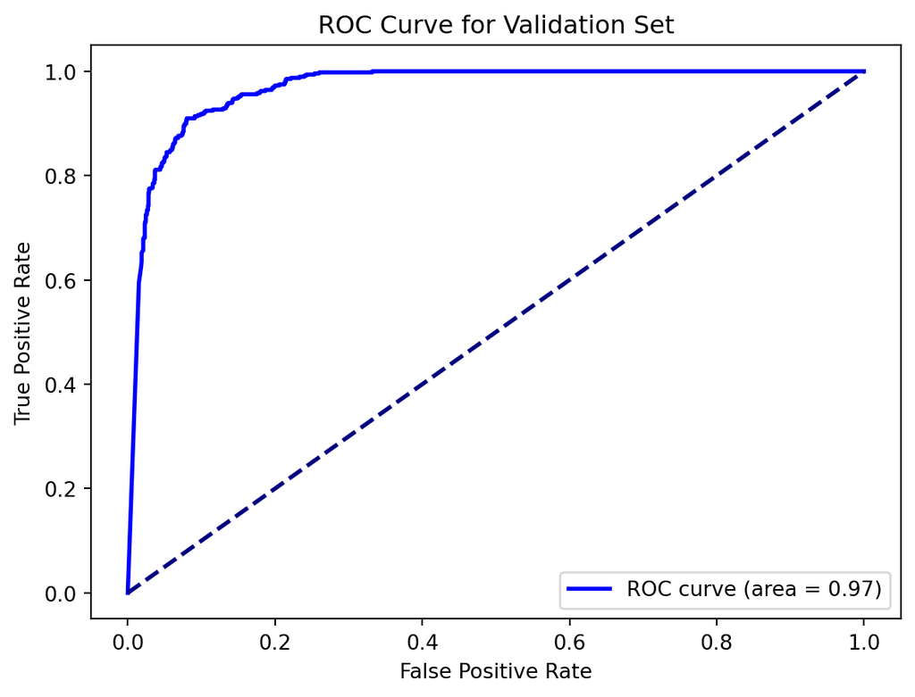

```python
# Predict probabilities for the validation set
yp = nb_model.predict_proba(X_val[sf])[:, 1]

# Compute ROC curve and ROC area for the validation set
fpr, tpr, _ = roc_curve(y_val, yp)
roc = auc(fpr, tpr)

# Plot ROC Curve for the validation set
plt.figure(figsize=(7, 5))
plt.plot(fpr, tpr, color='blue', lw=2, label='ROC curve (area = %0.2f)' % roc)
plt.plot([0, 1], [0, 1], color='navy', lw=2, linestyle='--')
plt.xlabel('False Positive Rate')
plt.ylabel('True Positive Rate')
plt.title('ROC Curve for Validation Set')
plt.legend(loc="lower right")
plt.show()
```

A receiver operating characteristic curve, or `ROC` curve, is a graphical plot that demonstrates the performance of a binary classifier model, it is the plot of the true positive rate `(TPR)` against the false positive rate `(FPR)` at each threshold setting. According to ROC curve, the `area = 0.97` sugggesting a good overall performance, where the `area = 1` indicating a perfect predictive model. The curve indicates a high true positive rate and a low false positive rate, reinforcing the interpretation that the model performs well.

## Conclusion

- Combining all the insights from the beginning of the analysis, we can conclude that the `Naive Bayes` model has demonstrated strong predictive performance on cardiovascular diseases `(CVD)` classifcation.
- The model’s accuracy levels on both the training and validation sets were pretty high, with the validation accuracy slightly higher that of the training set, which indicates that the model’s ability to generalize well to unseen data. Precision, recall, and F1 scores across both sets were largely balanced, suggesting that the model is reliable in its classification ability.
- Analysis by the ROC curve for the validation set proves this conclusion, with an AUC of `0.97` reflecting the model’s strong capability in distinguishing between different classes. The proximity of the curve to the upper left corner of the plot reinforces the model’s effectiveness in achieving a high accuracy.
- Overall, these results demonstrates that a Naive Bayes classifier that not only performs well statistically but also holds significant promise for real-world applications. Its high degree of accuracy and its strong balance of precision and recall suggest it could be a valuable tool in medical diagnostics. The consistency in the model’s performance across training and validation datasets indicates its robustness and suggests it would likely perform well in real-world situations, making it a trustworthy tool for predicting the presence of cardiovascular disease.